Skip to content

# Flex

## CSS Flexbox

- [Learning Material](https://www.youtube.com/watch?v=wsTv9y931o8&ab_channel=Coding2GO)

CSS `Flexbox`, or the `Flexible Box Layout Module`, is a layout model designed to provide a more efficient way to layout, align, and distribute space among elements within a container, even when their size is dynamic. It excels in creating flexible, responsive designs without relying on floats or positioning.

## Introduction to Flexbox

- `Flexbox` is optimized for laying out items in a **single dimension**—either **horizontally** (`row`) or **vertically** (`column`).
- It allows developers to control the alignment, spacing, and sizing of elements in a container.

### Core Concepts and Terminology

- **Flex container**: The `parent element` containing the items. It is defined using `display: flex`;.
- **Flex items**: The `child elements` within the flex container.
- **Main axis**: The primary axis along which the flex items are laid out (**horizontal by default**).
- **Cross axis**: The axis perpendicular to the main axis.

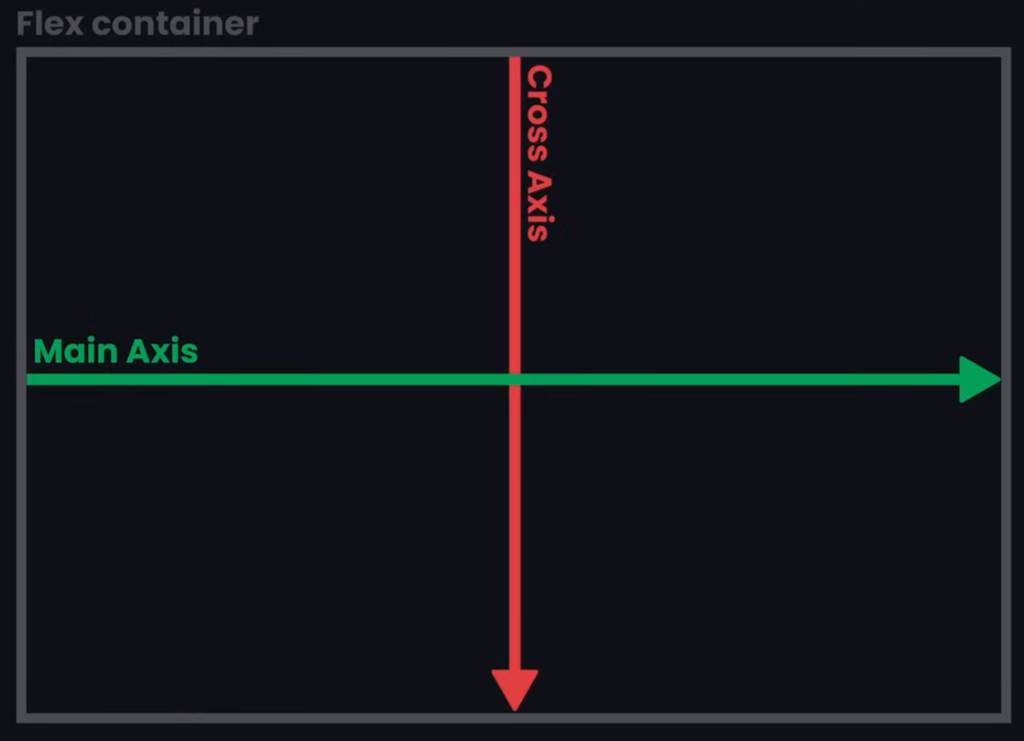

### Base Example

```
<head>
    <meta charset="UTF-8">
    <meta name="viewport" content="width=device-width, initial-scale=1.0">
    <title>Document</title>
    <style>
        body{
            display: flex;
            border: 8px solid black;
            justify-content: flex-start;
            flex-direction: row;
            align-items: center;
        }
        .box{
            background-color: blue;
            height: 200px;
            width: 200px;
            font-size: 40pt;
        }
    </style>
</head>
<body>
    <div class="box">1</div>
    <div class="box">2</div>
    <div class="box">3</div>
    <div class="box">4</div>
    <div class="box">5</div>
</body>
```

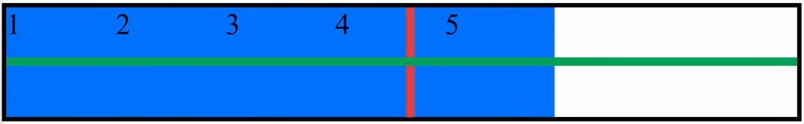

## Flex Container Properties

- The `flex container` is the element with `display: flex` or `display: inline-flex`.
- It controls the behavior of its child items (flex items).

### `display`

- `flex`: Creates a block-level flex container.
- `inline-flex`: Creates an inline-level flex container.

  ```
  .container {
  display: flex;
  }
  ```

### `justify-content`

Aligns items along the `main axis`.

- `flex-start` (**default**): Items align at the start.

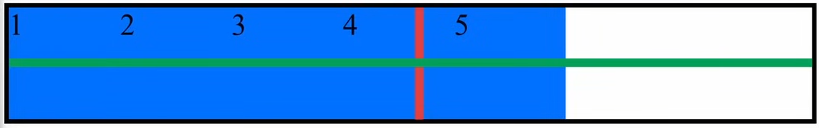

- `flex-end`: Items align at the end.

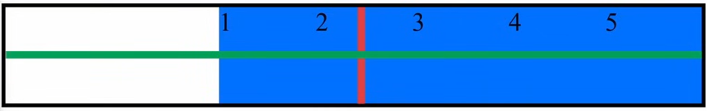

- `center`: Items align at the center.

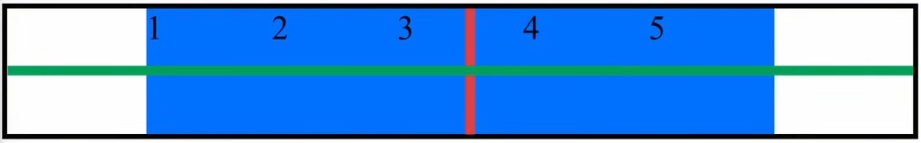

- `space-between`: Items spread out with space between them and start from the beginning.

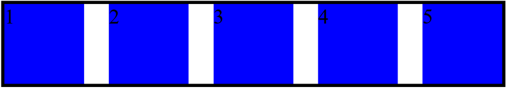

- `space-around`: Items spread out with space around them but not start from the beginning.

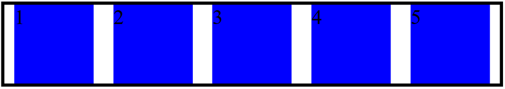

- `space-evenly`: Items have equal space between and around and ensure the equal gap.

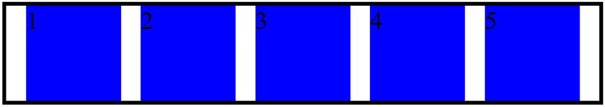

  ```
  .container {
  justify-content: center;
  }
  ```

### `align-items`

Aligns items along the cross axis.

- `flex-start` (**default**): Items align at the start.

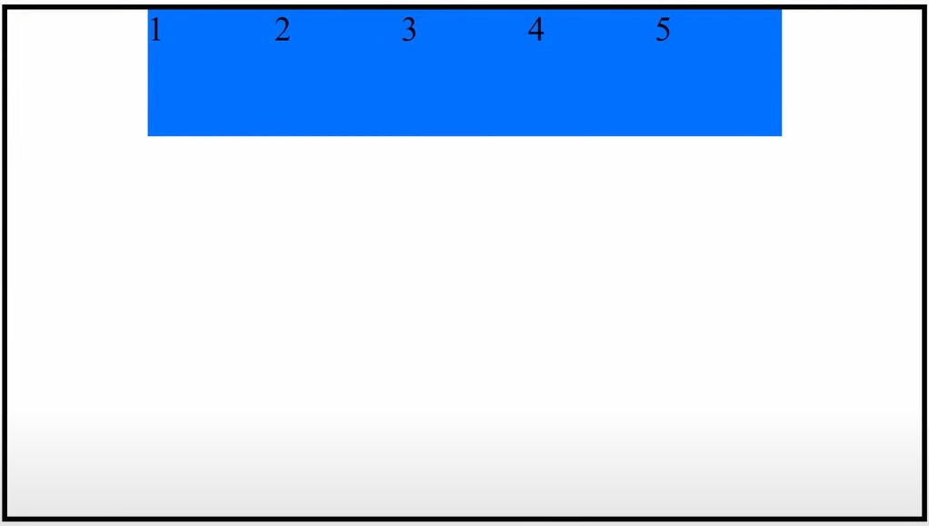

- `flex-end`: Items align at the end.

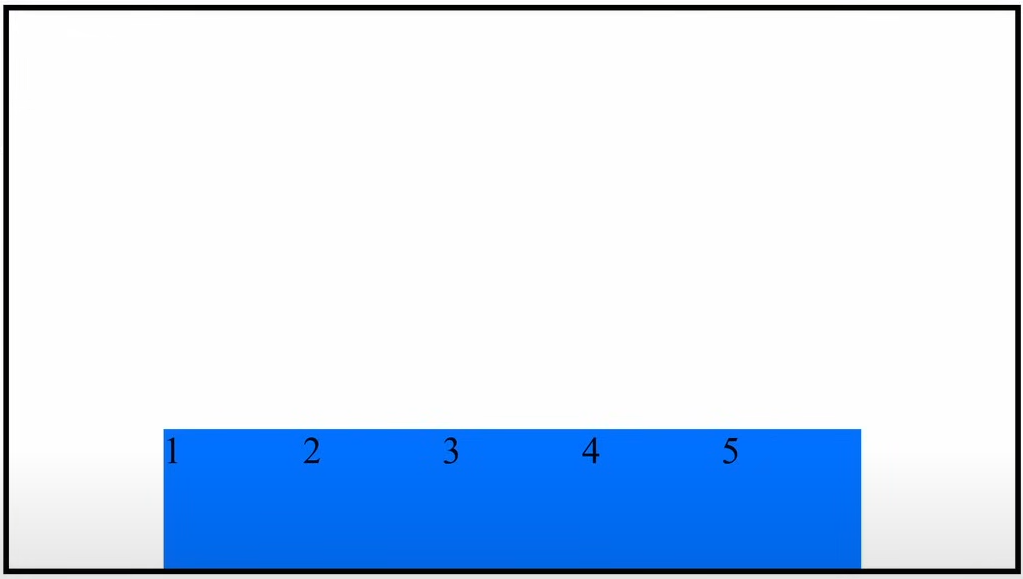

- `center`: Items align in the center.

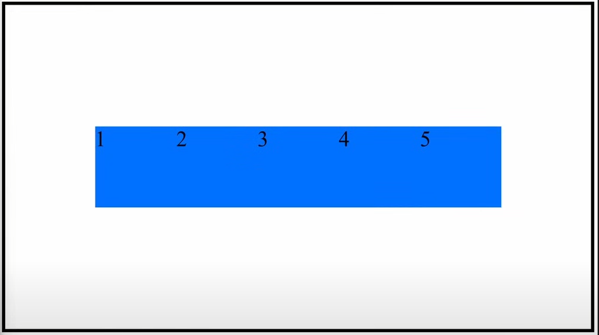

- `baseline`: Items align based on their text baselines.

  ```
  .container {
  align-items: flex-end;
  }
  ```

### `align-content`

Aligns a multi-line `flex container`'s content along the cross axis (only applies when flex-wrap is used).

- `align-items` works in every single row

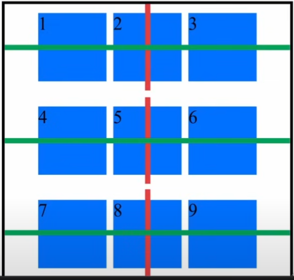

- `align-content` works for the whole container

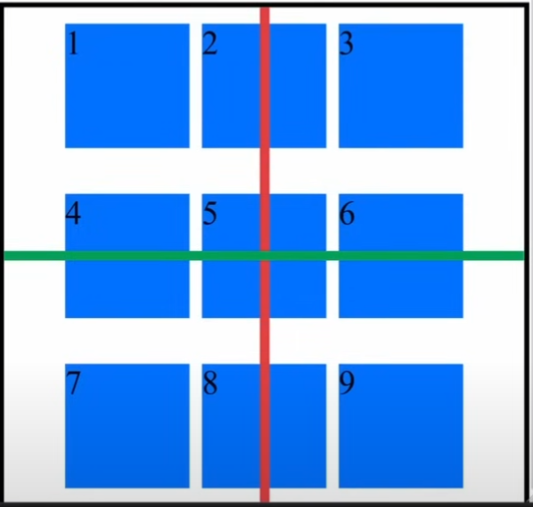

- `align-content : space-around;`

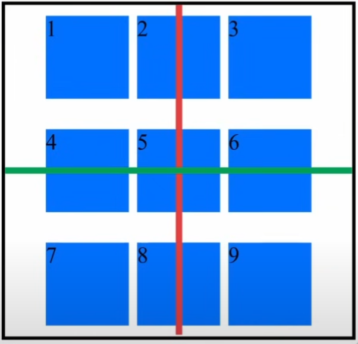

- `align-content : space-between;`

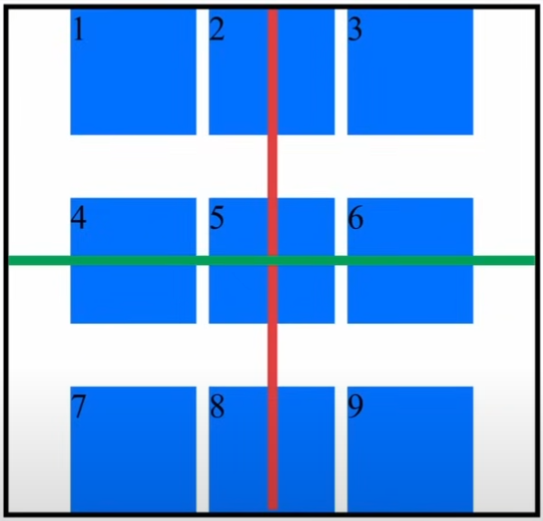

- `align-content : space-evenly;`

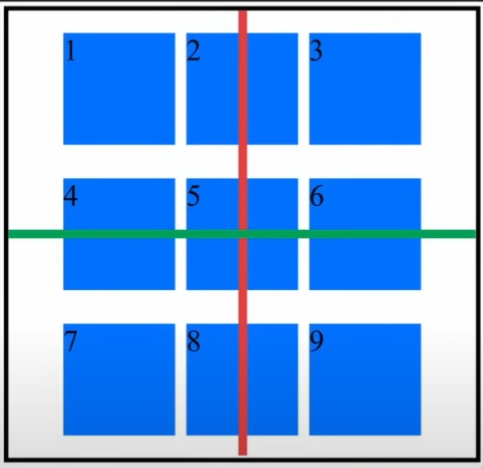

- `align-content : center;`

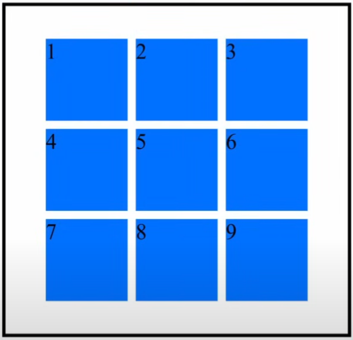

### `flex-direction`

Defines the direction of the `main axis`.

- `row` (default): Items arranged horizontally.

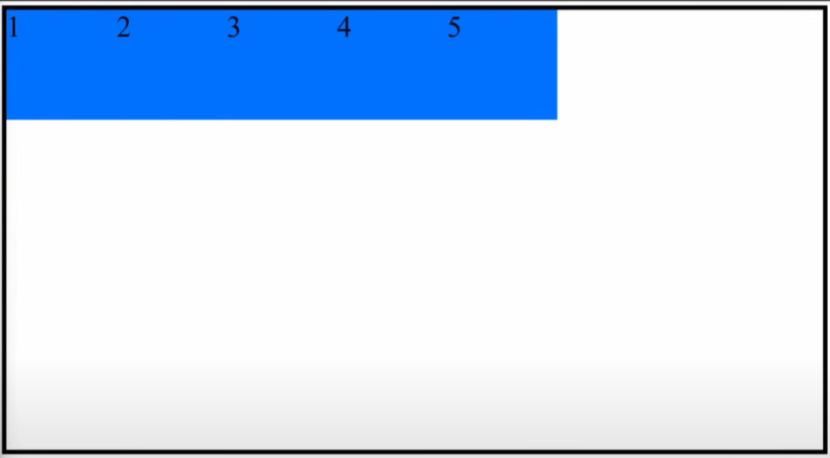

- `row-reverse`: Items arranged horizontally in reverse order.

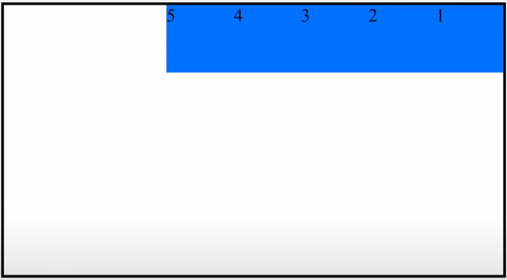

- `column`: Items arranged vertically.

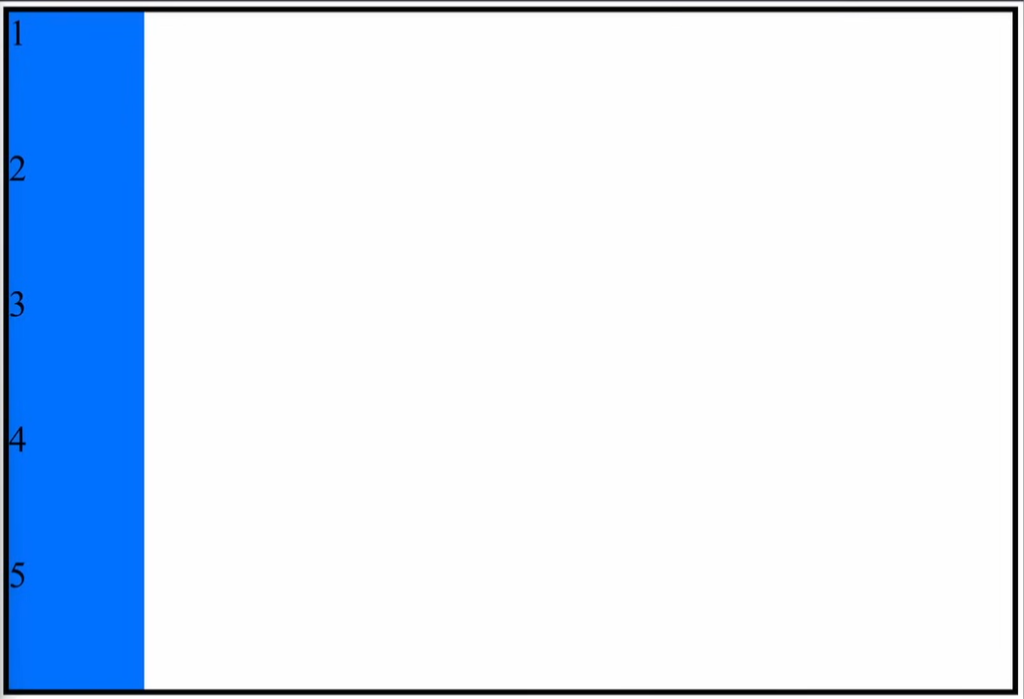

- `column-reverse`: Items arranged vertically in reverse order.

  ```
  .container {
  flex-direction: row;
  }
  ```

### `gap`

Defines the space between flex items.

```
.container {
gap: 20px; /* Adds 20px space between items */
}
```

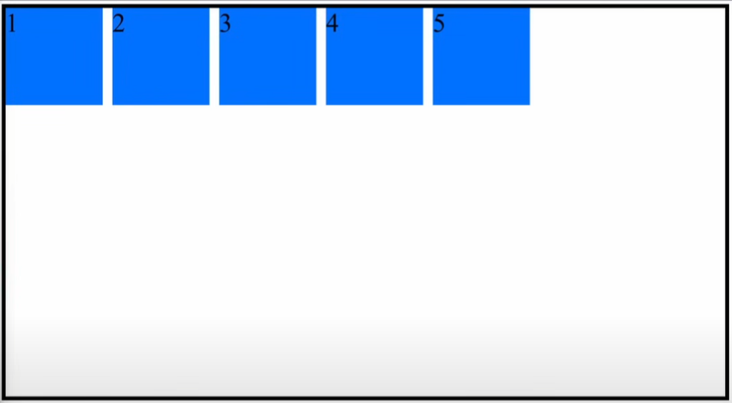

- `column-gap: 10px`

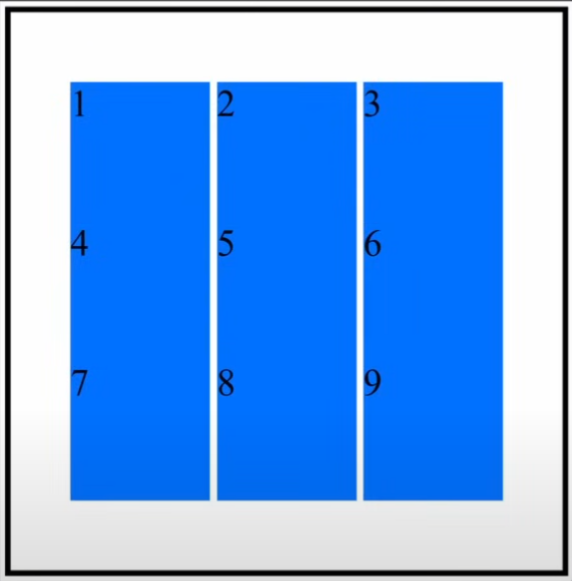

- `row-gap: 20px`

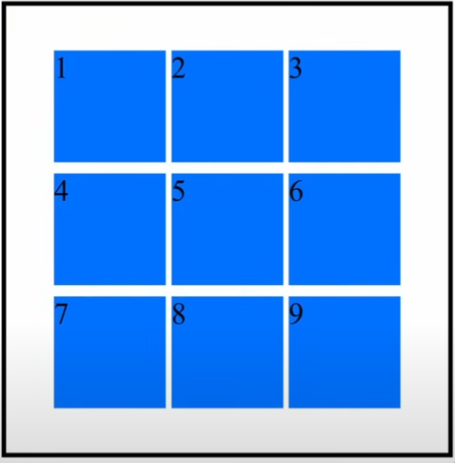

### `flex-wrap`

Controls whether items wrap onto the next line if they don’t fit.

- `nowrap` (**default**): All items are on one line.

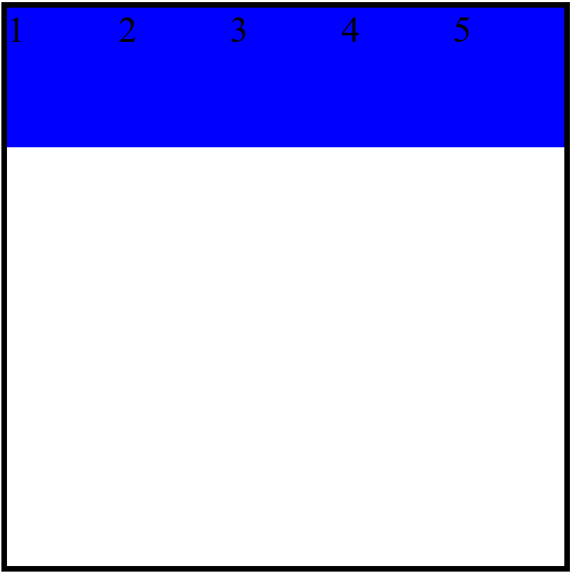

- `wrap`: Items wrap to the next line.

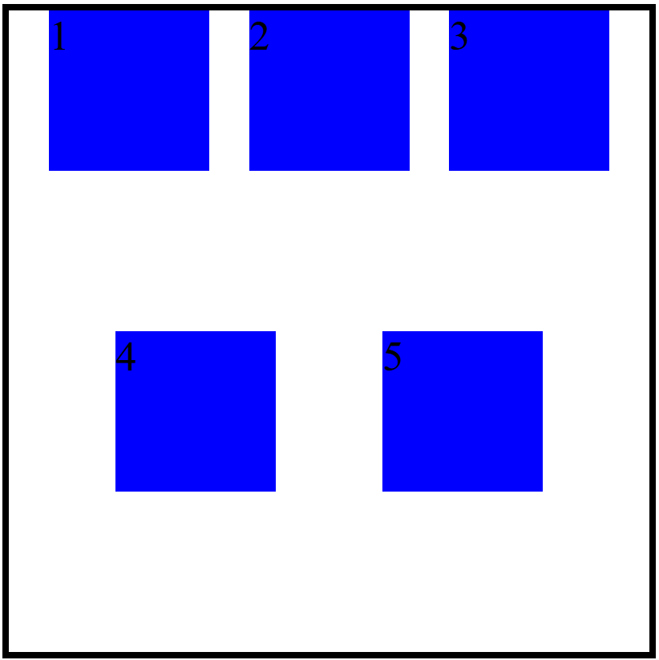

- `wrap-reverse`: Items wrap to the next line in reverse order.

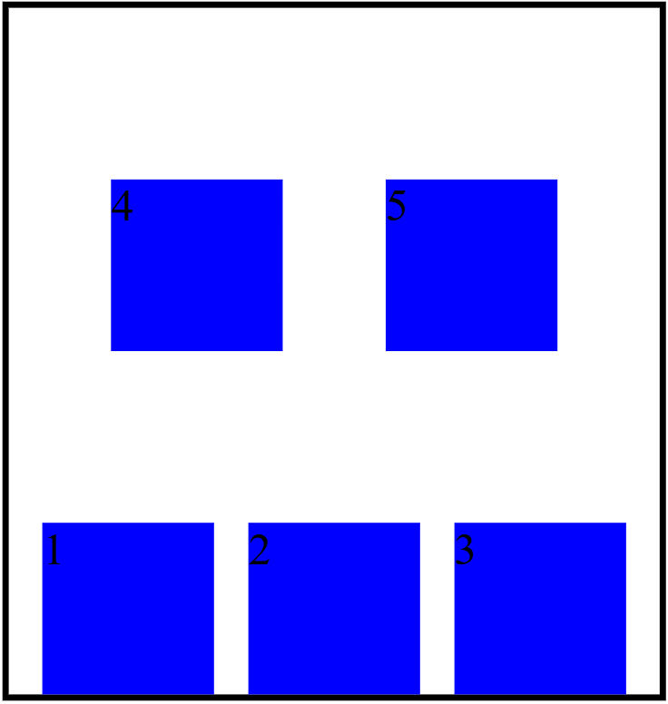

## Flex Item Properties

These properties are applied to the child elements (`flex items`).

- `flex-grow`

  Defines how much a flex item can grow relative to others.

  ```
  .box-1 {
  flex-grow: 1; /* grow as width change */
  }

  .box {
  flex-grow: 0; /* Prevent grow */
  }
  ```

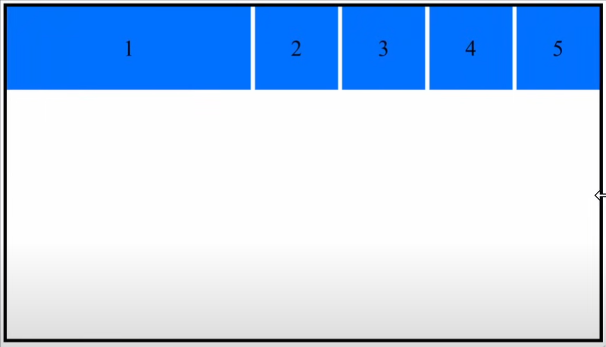

  - Actual example （Button are not allow to grow）

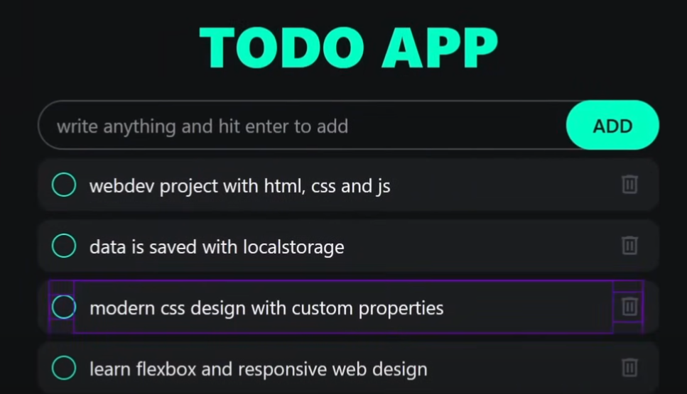

- `flex-shrink`

  Defines how much a flex item can shrink relative to others.

  ```
  .item {
  flex-shrink: 0; /* Prevents shrinking */
  }
  ```

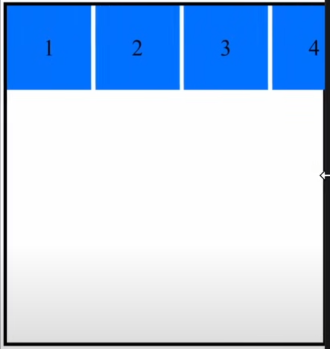

  ```
  .box-1 {
  flex-shrink: 0; /* Prevents shrinking */
  }

  .box{
  flex-shrink: 1;
  }
  ```

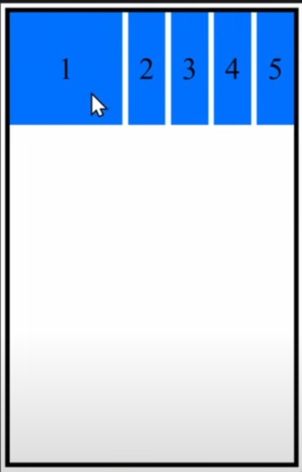

## Example

### Example 1: Horizontal Navigation Bar

```
<div class="navbar">
<div>Home</div>
<div>About</div>
<div>Services</div>
<div>Contact</div>
</div>

<style>
.navbar {
display: flex;
justify-content: space-around;
background: #333;
color: white;
padding: 10px;
}
.navbar div {
padding: 10px 20px;
}
</style>
```

### Example 2: Responsive Card Layout

```
<div class="cards">
  <div class="card">Card 1</div>
  <div class="card">Card 2</div>
  <div class="card">Card 3</div>
</div>

<style>
.cards {
  display: flex;
  flex-wrap: wrap;
  gap: 10px;
}
.card {
  flex: 1 1 calc(33.333% - 10px);
  background: #f4f4f4;
  padding: 20px;
  box-shadow: 0 2px 5px rgba(0,0,0,0.1);
}
</style>
```

Card 1

Card 2

Card 3

2025-09-18 2025-09-18